# Assignment 12: Predictive Modeling - Part 3

*How to do it?*:

- Open the Rmarkdown file of this assignment (link) in Rstudio.
- Right under each **question**, insert a code chunk (you can use the hotkey `Ctrl + Alt + I` to add a code chunk) and code the solution for the question.
- `Knit` the rmarkdown file (hotkey: `Ctrl + Alt + K`) to export an html.
- Publish the html file to your Githiub Page.

*Submission*: Submit the link on Github of the assignment to Blackboard.

1. Use the `PimaIndiansDiabetes` dataset. Use 15% data for testing. Use cross-validation with of 7 folds to tune random forest `(method='ranger')`. What are the parameters that produce the greatest accuracy? What is the testing accuracy.

```r
# Read in data
library(caret)
library(tidyverse)
df <- read_csv("PimaIndiansDiabetes.csv")

# Cleaning
df <- df |> rename(target = diabetes)
df$target <- as.factor(df$target)
colSums(is.na(df))
```

```
## pregnant  glucose pressure  triceps  insulin     mass pedigree      age
##        0        0        0        0        0        0        0        0
##   target
##        0
```

```r
# Train-Test Split
set.seed(42)
splitIndex <- createDataPartition(df$target, p = 0.85, list = FALSE)

df_train <- df[ splitIndex,]
df_test <- df[-splitIndex,]
```

```r
# Setting up CV with 7 folds
trControl = trainControl(method = "cv",
                         number = 7)
```

```r
# Check what parameters to tune
getModelInfo('ranger')$ranger$parameters
```

```
##       parameter     class                         label
## 1          mtry   numeric #Randomly Selected Predictors
## 2     splitrule character                Splitting Rule
## 3 min.node.size   numeric             Minimal Node Size
```

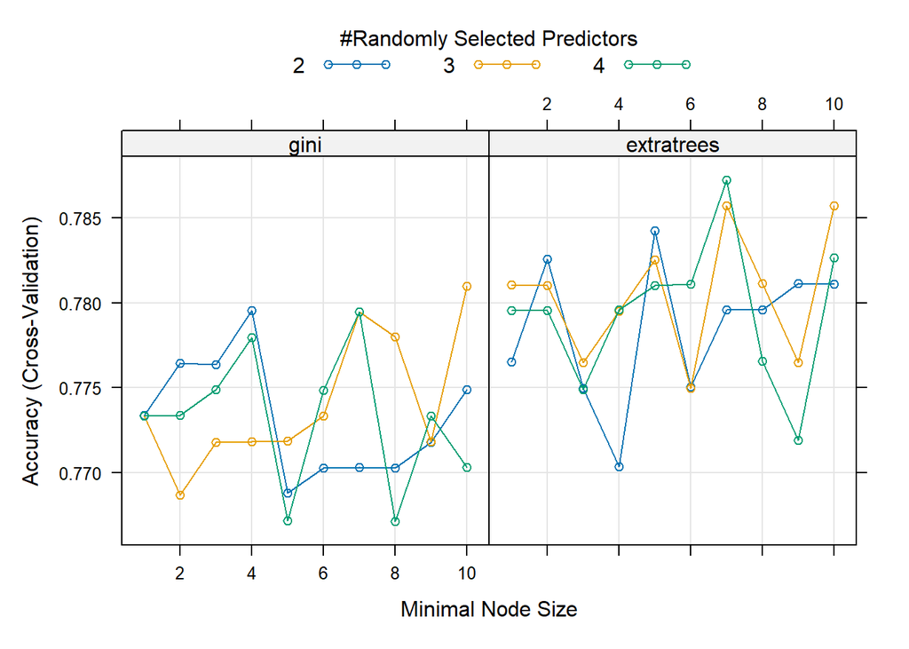

```r
# Random Forest - Ranger Method (CV - 7 folds)

tuneGrid = expand.grid(mtry = 2:4,
                       splitrule = c("gini", "extratrees"),
                       min.node.size = c(1:10))

forest_ranger <- train(target~., data = df_train,
                       method = "ranger",
                       trControl = trControl,
                       tuneGrid = tuneGrid)

pred <- predict(forest_ranger, df_test)

cm <- confusionMatrix(data = pred, reference = df_test$target, positive = "pos")


plot(forest_ranger)
```

```r
forest_ranger$bestTune
```

```
##    mtry  splitrule min.node.size
## 57    4 extratrees             7
```

```r
cm$overall[1]
```

```
##  Accuracy
## 0.7565217
```

**Answer:** The best parameters found were `mtry = 4`, `splitrule = extratrees`, and `min.node.size = 7`. The accuracy of this model is 0.7565217.

2. Use the `PimaIndiansDiabetes` dataset. Go to https://topepo.github.io/caret/available-models.html and pick a classification model. Tune the classification model using cross-validation of 7 folds.

```r
# Check what knn parameters to tune
getModelInfo('knn')$knn$parameters
```

```
##   parameter   class      label
## 1         k numeric #Neighbors
```

```r
sqrt(nrow(df))
```

```
## [1] 27.71281
```

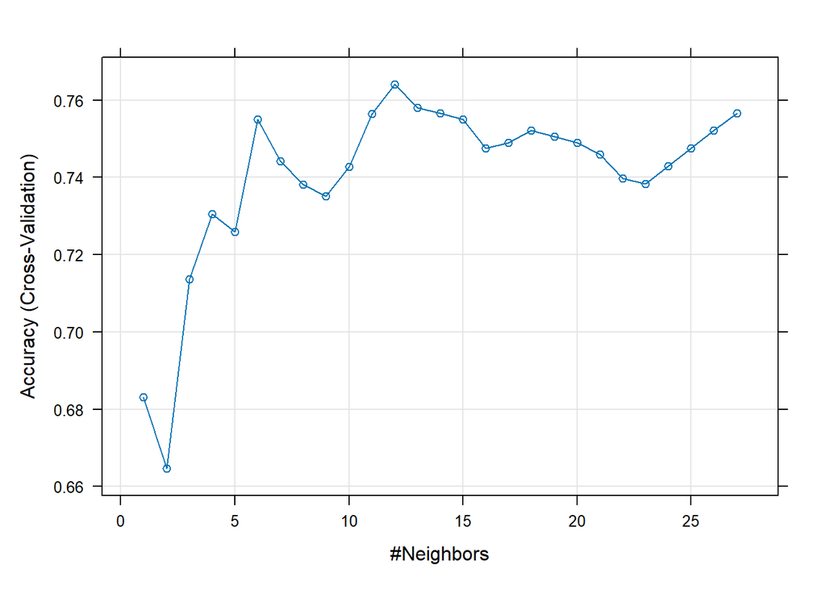

```r
# Classification Model (CV - 7 folds)
tuneGrid = expand.grid(k = 1:27) # upper bound of sqrt of # of observations as starting point

knn <- train(target~., data = df_train,
                       method = "knn",
                       trControl = trControl,
                       tuneGrid = tuneGrid)

pred <- predict(knn, df_test)

cm <- confusionMatrix(data = pred, reference = df_test$target, positive = "pos")


plot(knn)
```

```r
knn$bestTune
```

```
##     k
## 12 12
```

```r
cm$overall[1]
```

```
##  Accuracy
## 0.7391304
```

3. (Model Comparison) Use the `PimaIndiansDiabetes` dataset. Pick two models at [this link](https://topepo.github.io/caret/available-models.html) to compare using 7-fold cross validation method. Evaluate the accuracy of the final model on the test data.

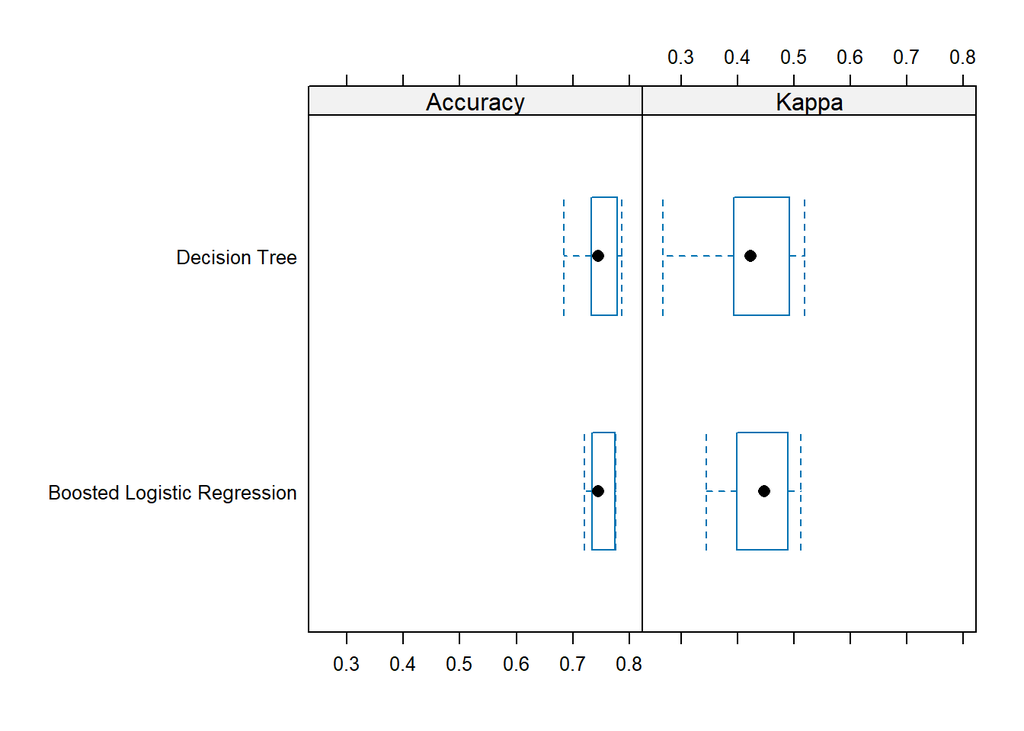

```r
# Model Comparison
library(caTools)
tree <- train(target~., data = df_train,
                       method = "rpart2",
                       trControl = trControl)

boost_logistic <- train(target~., data = df_train,
                       method = "LogitBoost",
                       trControl = trControl)

results <- resamples(list("Decision Tree" = tree,
                          "Boosted Logistic Regression" = boost_logistic))

bwplot(results)
```

```r
# Evaluate best model on testing data
pred <- predict(tree, df_test)

cm <- confusionMatrix(data = pred, reference = df_test$target, positive = "pos")

cm$overall[1]
```

```
##  Accuracy
## 0.7652174
```